# SSKalman

## Opgave 2

Vi tager udgangspunkt i data om kulmineulykker

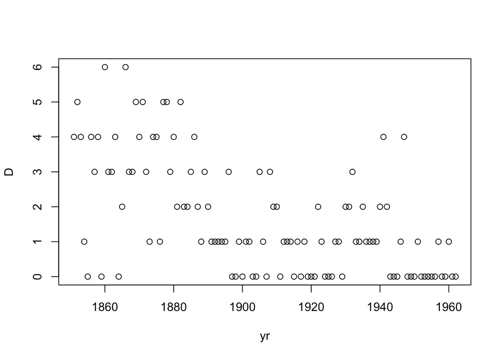

# Opgave 2.1

Ville en klassisk ARIMA model være vejen frem? Umiddelbart nej da den ikke er god til changepoints.

# Opgave 2.2

Er der tegn på seriel korrelation? Hvis det konkluderes at data er poissonfordelt, så er der jo ikke, men man kunne også se på det som korreleret, så vi kan bruge state space modeller.

# Opgave 2.3

Defnér en model, ved hjælp af DLM-pakken.

```r
ms <- dlm(m0=4, C0=6, FF=1, V=100, GG=1, W=10)
flt <- dlmFilter(D, mod=ms)
```

# Opgave 2.4

Forecastet er konstant med værdi:

```
## [1] 0.2234497
```

# Opgave 2.5

Fit varians parametrene

```r
build.fit <- function(parm){
  spec <- dlm(m0=4, C0=exp(parm[3]), FF=1, V=exp(parm[1]), GG=1, W=exp(parm[2]))
  spec
}

p.fit <- dlmMLE(D, parm=c(1, 1, 1), build.fit)$par
ms.fit <- build.fit( p.fit )
flt.fit <- dlmFilter(D, mod=ms.fit)
```

# Opgave 2.6

Plot de fittede værdier, samt forecastet

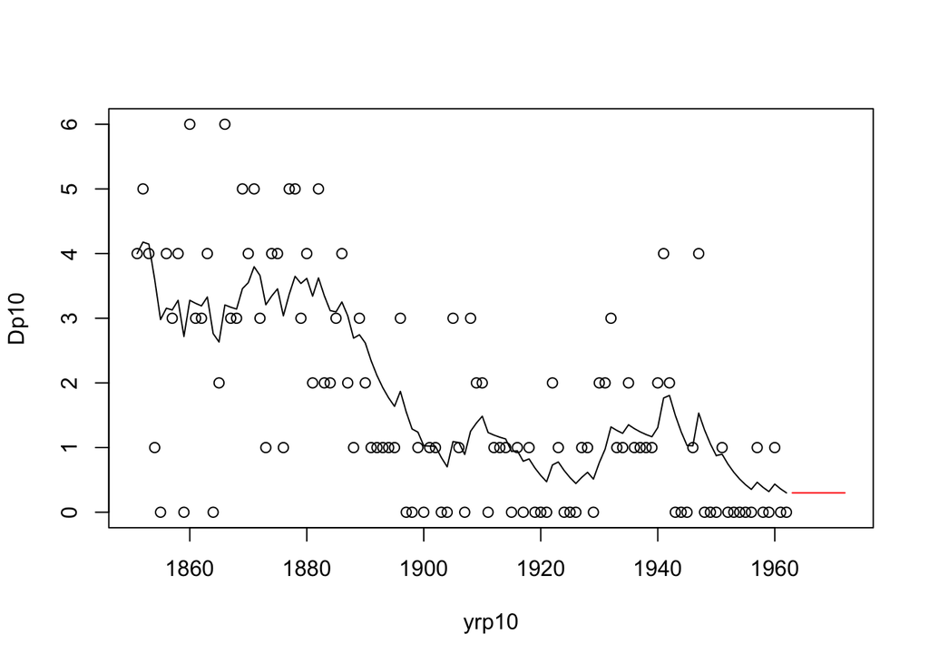

Forecastet af den fittede model er også konstant med værdi:

```
## [1] 0.2995939
```

# Opgave 2.7

Der ser ud til at være et changepoint, hvordan håndterer vi det? Vi identificerer changepointet, her med en funktion i R.

```r
cpt.mean(D)
```

```
## Class 'cpt' : Changepoint Object
##        ~~   : S4 class containing 12 slots with names
##               cpttype date version data.set method test.stat pen.type pen.value minseglen cpts ncpts.max param.est
##
## Created on  : Thu Oct  6 12:10:37 2016
##
## summary(.)  :
## ----------
## Created Using changepoint version 2.2.2
## Changepoint type      : Change in mean
## Method of analysis    : AMOC
## Test Statistic  : Normal
## Type of penalty       : MBIC with value, 14.1555
## Minimum Segment Length : 1
## Maximum no. of cpts   : 1
## Changepoint Locations : 36
```

Så forbereder vi en øget varians omkring changepointet.

```r
x <- rep(1, length(D))
x[30:45] <- 5
```

Sætter DLM op igen

```r
X <- matrix(x)
build.cp <- function(parm){
  Z <- X
  Z[,1] <- exp(parm[1])*X[,1]
  spec <- dlm(m0=4, C0=exp(parm[3]), FF=1, V=exp(parm[2]), GG=1, JW=1, W=exp(parm[4]), X=Z)
  spec
}
p.cp <- dlmMLE(D, parm=c(1, 1, 1,1), build.cp)$par
ms.cp <- build.cp( p.cp )
flt.cp <- dlmFilter(D, mod=ms.cp)
```

# Opgave 2.8

Plot de fittede værdier, samt forecastet

[figure not shown]

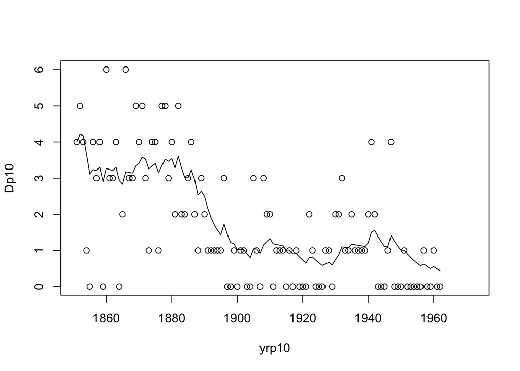

Vi har ikke kunnet forecaste med den sædvanlige funktion i changepoint modellen, men vi ved at den kommer til at være konstant og ligge ud for sidste punkt som er

```
## [1] 0.4402181
```

# Opgave 2.9

Hvad kan vi så sige om det hele?

Det bliver bedre og bedre.